# Risk Factor Analysis

## Outcome Variable

**Outcome Variable:** ever_co

## Predictor Variables

**Intervention Variable:** feducyrs

**Adjustment Set:**

unadjusted

## Stratifying Variables

The analysis was stratified on these variable(s):

- agecat
- studyid
- country

## Data Summary

| agecat | studyid | country | feducyrs | ever_co | n_cell | n |
| --- | --- | --- | --- | --- | --- | --- |
| 0-24 months | ki0047075b-MAL-ED | BANGLADESH | High | 0 | 50 | 147 |
| 0-24 months | ki0047075b-MAL-ED | BANGLADESH | High | 1 | 4 | 147 |
| 0-24 months | ki0047075b-MAL-ED | BANGLADESH | Low | 0 | 33 | 147 |
| 0-24 months | ki0047075b-MAL-ED | BANGLADESH | Low | 1 | 6 | 147 |
| 0-24 months | ki0047075b-MAL-ED | BANGLADESH | Medium | 0 | 45 | 147 |
| 0-24 months | ki0047075b-MAL-ED | BANGLADESH | Medium | 1 | 9 | 147 |
| 0-24 months | ki0047075b-MAL-ED | INDIA | High | 0 | 36 | 147 |
| 0-24 months | ki0047075b-MAL-ED | INDIA | High | 1 | 8 | 147 |
| 0-24 months | ki0047075b-MAL-ED | INDIA | Low | 0 | 46 | 147 |
| 0-24 months | ki0047075b-MAL-ED | INDIA | Low | 1 | 13 | 147 |
| 0-24 months | ki0047075b-MAL-ED | INDIA | Medium | 0 | 36 | 147 |
| 0-24 months | ki0047075b-MAL-ED | INDIA | Medium | 1 | 8 | 147 |
| 0-24 months | ki0047075b-MAL-ED | NEPAL | High | 0 | 39 | 98 |
| 0-24 months | ki0047075b-MAL-ED | NEPAL | High | 1 | 3 | 98 |
| 0-24 months | ki0047075b-MAL-ED | NEPAL | Low | 0 | 26 | 98 |
| 0-24 months | ki0047075b-MAL-ED | NEPAL | Low | 1 | 2 | 98 |
| 0-24 months | ki0047075b-MAL-ED | NEPAL | Medium | 0 | 22 | 98 |
| 0-24 months | ki0047075b-MAL-ED | NEPAL | Medium | 1 | 6 | 98 |
| 0-24 months | ki0047075b-MAL-ED | PERU | High | 0 | 116 | 250 |
| 0-24 months | ki0047075b-MAL-ED | PERU | High | 1 | 4 | 250 |
| 0-24 months | ki0047075b-MAL-ED | PERU | Low | 0 | 68 | 250 |
| 0-24 months | ki0047075b-MAL-ED | PERU | Low | 1 | 1 | 250 |
| 0-24 months | ki0047075b-MAL-ED | PERU | Medium | 0 | 58 | 250 |
| 0-24 months | ki0047075b-MAL-ED | PERU | Medium | 1 | 3 | 250 |
| 0-24 months | ki0047075b-MAL-ED | SOUTH AFRICA | High | 0 | 40 | 110 |
| 0-24 months | ki0047075b-MAL-ED | SOUTH AFRICA | High | 1 | 3 | 110 |
| 0-24 months | ki0047075b-MAL-ED | SOUTH AFRICA | Low | 0 | 34 | 110 |
| 0-24 months | ki0047075b-MAL-ED | SOUTH AFRICA | Low | 1 | 3 | 110 |
| 0-24 months | ki0047075b-MAL-ED | SOUTH AFRICA | Medium | 0 | 27 | 110 |
| 0-24 months | ki0047075b-MAL-ED | SOUTH AFRICA | Medium | 1 | 3 | 110 |

[output cut: 330 more lines]

The following strata were considered:

- agecat: 0-24 months, studyid: ki0047075b-MAL-ED, country: BANGLADESH
- agecat: 0-24 months, studyid: ki0047075b-MAL-ED, country: INDIA
- agecat: 0-24 months, studyid: ki0047075b-MAL-ED, country: NEPAL
- agecat: 0-24 months, studyid: ki0047075b-MAL-ED, country: PERU
- agecat: 0-24 months, studyid: ki0047075b-MAL-ED, country: SOUTH AFRICA
- agecat: 0-24 months, studyid: ki0047075b-MAL-ED, country: TANZANIA, UNITED REPUBLIC OF
- agecat: 0-24 months, studyid: ki1000304b-SAS-CompFeed, country: INDIA
- agecat: 0-24 months, studyid: ki1000304b-SAS-FoodSuppl, country: INDIA
- agecat: 0-24 months, studyid: ki1017093b-PROVIDE, country: BANGLADESH
- agecat: 0-24 months, studyid: ki1017093c-NIH-Crypto, country: BANGLADESH
- agecat: 0-24 months, studyid: ki1066203-TanzaniaChild2, country: TANZANIA, UNITED REPUBLIC OF
- agecat: 0-24 months, studyid: ki1113344-GMS-Nepal, country: NEPAL
- agecat: 0-24 months, studyid: ki1119695-PROBIT, country: BELARUS
- agecat: 0-24 months, studyid: ki1126311-ZVITAMBO, country: ZIMBABWE
- agecat: 0-24 months, studyid: ki1135781-COHORTS, country: GUATEMALA
- agecat: 0-24 months, studyid: ki1135781-COHORTS, country: INDIA
- agecat: 0-24 months, studyid: ki1135781-COHORTS, country: PHILIPPINES
- agecat: 0-24 months, studyid: ki1148112-LCNI-5, country: MALAWI
- agecat: 0-24 months, studyid: kiGH5241-JiVitA-3, country: BANGLADESH
- agecat: 0-24 months, studyid: kiGH5241-JiVitA-4, country: BANGLADESH
- agecat: 0-6 months, studyid: ki0047075b-MAL-ED, country: BANGLADESH
- agecat: 0-6 months, studyid: ki0047075b-MAL-ED, country: INDIA
- agecat: 0-6 months, studyid: ki0047075b-MAL-ED, country: NEPAL
- agecat: 0-6 months, studyid: ki0047075b-MAL-ED, country: PERU
- agecat: 0-6 months, studyid: ki0047075b-MAL-ED, country: SOUTH AFRICA
- agecat: 0-6 months, studyid: ki0047075b-MAL-ED, country: TANZANIA, UNITED REPUBLIC OF
- agecat: 0-6 months, studyid: ki1000304b-SAS-CompFeed, country: INDIA
- agecat: 0-6 months, studyid: ki1000304b-SAS-FoodSuppl, country: INDIA
- agecat: 0-6 months, studyid: ki1017093b-PROVIDE, country: BANGLADESH
- agecat: 0-6 months, studyid: ki1017093c-NIH-Crypto, country: BANGLADESH
- agecat: 0-6 months, studyid: ki1066203-TanzaniaChild2, country: TANZANIA, UNITED REPUBLIC OF
- agecat: 0-6 months, studyid: ki1113344-GMS-Nepal, country: NEPAL
- agecat: 0-6 months, studyid: ki1119695-PROBIT, country: BELARUS
- agecat: 0-6 months, studyid: ki1126311-ZVITAMBO, country: ZIMBABWE
- agecat: 0-6 months, studyid: ki1135781-COHORTS, country: GUATEMALA
- agecat: 0-6 months, studyid: ki1135781-COHORTS, country: INDIA
- agecat: 0-6 months, studyid: ki1135781-COHORTS, country: PHILIPPINES
- agecat: 0-6 months, studyid: ki1148112-LCNI-5, country: MALAWI
- agecat: 0-6 months, studyid: kiGH5241-JiVitA-3, country: BANGLADESH
- agecat: 0-6 months, studyid: kiGH5241-JiVitA-4, country: BANGLADESH
- agecat: 6-24 months, studyid: ki0047075b-MAL-ED, country: BANGLADESH
- agecat: 6-24 months, studyid: ki0047075b-MAL-ED, country: INDIA
- agecat: 6-24 months, studyid: ki0047075b-MAL-ED, country: NEPAL
- agecat: 6-24 months, studyid: ki0047075b-MAL-ED, country: PERU
- agecat: 6-24 months, studyid: ki0047075b-MAL-ED, country: SOUTH AFRICA
- agecat: 6-24 months, studyid: ki0047075b-MAL-ED, country: TANZANIA, UNITED REPUBLIC OF
- agecat: 6-24 months, studyid: ki1000304b-SAS-CompFeed, country: INDIA
- agecat: 6-24 months, studyid: ki1000304b-SAS-FoodSuppl, country: INDIA
- agecat: 6-24 months, studyid: ki1017093b-PROVIDE, country: BANGLADESH
- agecat: 6-24 months, studyid: ki1017093c-NIH-Crypto, country: BANGLADESH
- agecat: 6-24 months, studyid: ki1066203-TanzaniaChild2, country: TANZANIA, UNITED REPUBLIC OF
- agecat: 6-24 months, studyid: ki1113344-GMS-Nepal, country: NEPAL
- agecat: 6-24 months, studyid: ki1119695-PROBIT, country: BELARUS
- agecat: 6-24 months, studyid: ki1126311-ZVITAMBO, country: ZIMBABWE
- agecat: 6-24 months, studyid: ki1135781-COHORTS, country: GUATEMALA
- agecat: 6-24 months, studyid: ki1135781-COHORTS, country: INDIA
- agecat: 6-24 months, studyid: ki1135781-COHORTS, country: PHILIPPINES
- agecat: 6-24 months, studyid: ki1148112-LCNI-5, country: MALAWI
- agecat: 6-24 months, studyid: kiGH5241-JiVitA-3, country: BANGLADESH
- agecat: 6-24 months, studyid: kiGH5241-JiVitA-4, country: BANGLADESH

### Dropped Strata

Some strata were dropped due to rare outcomes:

- agecat: 0-24 months, studyid: ki0047075b-MAL-ED, country: BANGLADESH
- agecat: 0-24 months, studyid: ki0047075b-MAL-ED, country: NEPAL
- agecat: 0-24 months, studyid: ki0047075b-MAL-ED, country: PERU
- agecat: 0-24 months, studyid: ki0047075b-MAL-ED, country: SOUTH AFRICA
- agecat: 0-24 months, studyid: ki0047075b-MAL-ED, country: TANZANIA, UNITED REPUBLIC OF
- agecat: 0-24 months, studyid: ki1119695-PROBIT, country: BELARUS
- agecat: 0-6 months, studyid: ki0047075b-MAL-ED, country: BANGLADESH
- agecat: 0-6 months, studyid: ki0047075b-MAL-ED, country: INDIA
- agecat: 0-6 months, studyid: ki0047075b-MAL-ED, country: NEPAL
- agecat: 0-6 months, studyid: ki0047075b-MAL-ED, country: PERU
- agecat: 0-6 months, studyid: ki0047075b-MAL-ED, country: SOUTH AFRICA
- agecat: 0-6 months, studyid: ki0047075b-MAL-ED, country: TANZANIA, UNITED REPUBLIC OF
- agecat: 0-6 months, studyid: ki1017093c-NIH-Crypto, country: BANGLADESH
- agecat: 0-6 months, studyid: ki1066203-TanzaniaChild2, country: TANZANIA, UNITED REPUBLIC OF
- agecat: 0-6 months, studyid: ki1119695-PROBIT, country: BELARUS
- agecat: 0-6 months, studyid: ki1135781-COHORTS, country: GUATEMALA
- agecat: 0-6 months, studyid: ki1148112-LCNI-5, country: MALAWI
- agecat: 0-6 months, studyid: kiGH5241-JiVitA-4, country: BANGLADESH
- agecat: 6-24 months, studyid: ki0047075b-MAL-ED, country: BANGLADESH
- agecat: 6-24 months, studyid: ki0047075b-MAL-ED, country: NEPAL
- agecat: 6-24 months, studyid: ki0047075b-MAL-ED, country: PERU
- agecat: 6-24 months, studyid: ki0047075b-MAL-ED, country: SOUTH AFRICA
- agecat: 6-24 months, studyid: ki0047075b-MAL-ED, country: TANZANIA, UNITED REPUBLIC OF
- agecat: 6-24 months, studyid: ki1119695-PROBIT, country: BELARUS

## Methods Detail

We’re interested in the causal parameters $E[Y_a]$ for all values of $a \in \mathcal{A}$. These parameters represent the mean outcome if, possibly contrary to fact, we intervened to set all units to have $A=a$. Under the randomization and positivity assumptions, these are identified by the statistical parameters $\psi_a=E_W[E_{Y|A,W}(Y|A=a,W)]$. In addition, we’re interested in the mean of $Y$, $E[Y]$ under no intervention (the observed mean). We will estimate these parameters by using SuperLearner to fit the relevant likelihood factors – $E_{Y|A,W}(Y|A=a,W)$ and $p(A=a|W)$, and then updating our likelihood fit using a joint TMLE.

For unadjusted analyses ($W=\{\}$), initial likelihoods were estimated using Lrnr_glm to estimate the simple $E(Y|A)$ and Lrnr_mean to estimate $p(A)$. For adjusted analyses, a small library containing Lrnr_glmnet, Lrnr_xgboost, and Lrnr_mean was used.

Having estimated these parameters, we will then use the delta method to estimate relative risks and attributable risks relative to a prespecified baseline level of $A$.

# Results Detail

## Results Plots

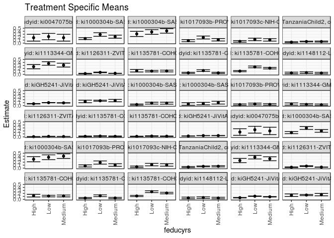

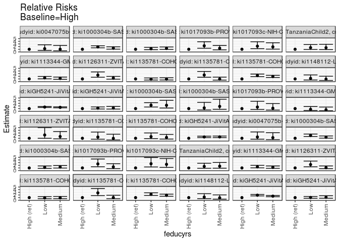

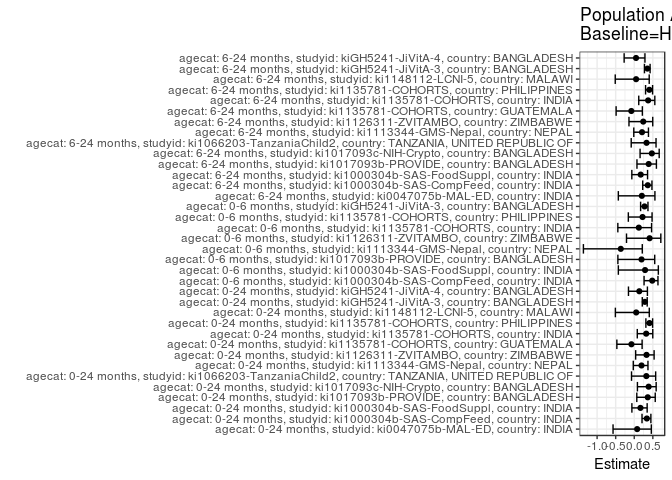

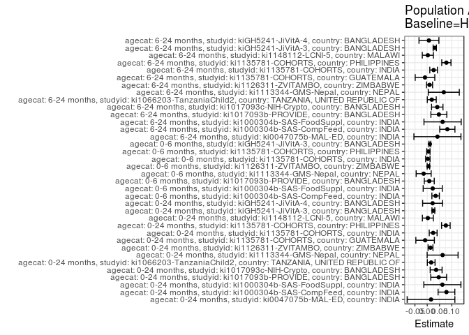

## Results Table

### Parameter: TSM

| agecat | studyid | country | intervention_level | baseline_level | estimate | ci_lower | ci_upper |
| --- | --- | --- | --- | --- | --- | --- | --- |
| 0-24 months | ki0047075b-MAL-ED | INDIA | High | NA | 0.1818182 | 0.0674652 | 0.2961712 |
| 0-24 months | ki0047075b-MAL-ED | INDIA | Low | NA | 0.2203390 | 0.1142176 | 0.3264604 |
| 0-24 months | ki0047075b-MAL-ED | INDIA | Medium | NA | 0.1818182 | 0.0674652 | 0.2961712 |
| 0-24 months | ki1000304b-SAS-CompFeed | INDIA | High | NA | 0.1528497 | 0.1210513 | 0.1846481 |
| 0-24 months | ki1000304b-SAS-CompFeed | INDIA | Low | NA | 0.2892691 | 0.2289782 | 0.3495599 |
| 0-24 months | ki1000304b-SAS-CompFeed | INDIA | Medium | NA | 0.2162162 | 0.1648638 | 0.2675687 |
| 0-24 months | ki1000304b-SAS-FoodSuppl | INDIA | High | NA | 0.3090909 | 0.2226289 | 0.3955529 |
| 0-24 months | ki1000304b-SAS-FoodSuppl | INDIA | Low | NA | 0.3741497 | 0.2958306 | 0.4524687 |
| 0-24 months | ki1000304b-SAS-FoodSuppl | INDIA | Medium | NA | 0.4099379 | 0.3338767 | 0.4859991 |
| 0-24 months | ki1017093b-PROVIDE | BANGLADESH | High | NA | 0.0818966 | 0.0465869 | 0.1172062 |
| 0-24 months | ki1017093b-PROVIDE | BANGLADESH | Low | NA | 0.1890756 | 0.1392930 | 0.2388583 |
| 0-24 months | ki1017093b-PROVIDE | BANGLADESH | Medium | NA | 0.1130435 | 0.0720921 | 0.1539949 |
| 0-24 months | ki1017093c-NIH-Crypto | BANGLADESH | High | NA | 0.0574324 | 0.0309094 | 0.0839555 |
| 0-24 months | ki1017093c-NIH-Crypto | BANGLADESH | Low | NA | 0.1239669 | 0.0824199 | 0.1655140 |
| 0-24 months | ki1017093c-NIH-Crypto | BANGLADESH | Medium | NA | 0.1090909 | 0.0678684 | 0.1503134 |
| 0-24 months | ki1066203-TanzaniaChild2 | TANZANIA, UNITED REPUBLIC OF | High | NA | 0.0334076 | 0.0167826 | 0.0500325 |
| 0-24 months | ki1066203-TanzaniaChild2 | TANZANIA, UNITED REPUBLIC OF | Low | NA | 0.0535433 | 0.0411599 | 0.0659267 |
| 0-24 months | ki1066203-TanzaniaChild2 | TANZANIA, UNITED REPUBLIC OF | Medium | NA | 0.0527108 | 0.0357109 | 0.0697107 |
| 0-24 months | ki1113344-GMS-Nepal | NEPAL | High | NA | 0.2585034 | 0.1876699 | 0.3293369 |
| 0-24 months | ki1113344-GMS-Nepal | NEPAL | Low | NA | 0.3657588 | 0.3068245 | 0.4246930 |
| 0-24 months | ki1113344-GMS-Nepal | NEPAL | Medium | NA | 0.3096447 | 0.2450280 | 0.3742614 |
| 0-24 months | ki1126311-ZVITAMBO | ZIMBABWE | High | NA | 0.0272177 | 0.0170916 | 0.0373438 |
| 0-24 months | ki1126311-ZVITAMBO | ZIMBABWE | Low | NA | 0.0661700 | 0.0559707 | 0.0763693 |
| 0-24 months | ki1126311-ZVITAMBO | ZIMBABWE | Medium | NA | 0.0362699 | 0.0326564 | 0.0398835 |
| 0-24 months | ki1135781-COHORTS | GUATEMALA | High | NA | 0.1212121 | 0.0791072 | 0.1633171 |
| 0-24 months | ki1135781-COHORTS | GUATEMALA | Low | NA | 0.1093190 | 0.0834180 | 0.1352200 |
| 0-24 months | ki1135781-COHORTS | GUATEMALA | Medium | NA | 0.1123596 | 0.0830055 | 0.1417136 |
| 0-24 months | ki1135781-COHORTS | INDIA | High | NA | 0.0511464 | 0.0330074 | 0.0692854 |
| 0-24 months | ki1135781-COHORTS | INDIA | Low | NA | 0.1271186 | 0.0970572 | 0.1571801 |
| 0-24 months | ki1135781-COHORTS | INDIA | Medium | NA | 0.0490196 | 0.0280621 | 0.0699771 |

[output cut: 78 more lines]

### Parameter: E(Y)

| agecat | studyid | country | intervention_level | baseline_level | estimate | ci_lower | ci_upper |
| --- | --- | --- | --- | --- | --- | --- | --- |
| 0-24 months | ki0047075b-MAL-ED | INDIA | NA | NA | 0.1972789 | 0.1327292 | 0.2618286 |
| 0-24 months | ki1000304b-SAS-CompFeed | INDIA | NA | NA | 0.2311258 | 0.1911027 | 0.2711489 |
| 0-24 months | ki1000304b-SAS-FoodSuppl | INDIA | NA | NA | 0.3708134 | 0.3244530 | 0.4171738 |
| 0-24 months | ki1017093b-PROVIDE | BANGLADESH | NA | NA | 0.1285714 | 0.1037574 | 0.1533855 |
| 0-24 months | ki1017093c-NIH-Crypto | BANGLADESH | NA | NA | 0.0936675 | 0.0729118 | 0.1144233 |
| 0-24 months | ki1066203-TanzaniaChild2 | TANZANIA, UNITED REPUBLIC OF | NA | NA | 0.0495174 | 0.0408052 | 0.0582296 |
| 0-24 months | ki1113344-GMS-Nepal | NEPAL | NA | NA | 0.3211314 | 0.2837715 | 0.3584914 |
| 0-24 months | ki1126311-ZVITAMBO | ZIMBABWE | NA | NA | 0.0406402 | 0.0373164 | 0.0439640 |
| 0-24 months | ki1135781-COHORTS | GUATEMALA | NA | NA | 0.1126418 | 0.0949950 | 0.1302886 |
| 0-24 months | ki1135781-COHORTS | INDIA | NA | NA | 0.0753283 | 0.0617252 | 0.0889313 |
| 0-24 months | ki1135781-COHORTS | PHILIPPINES | NA | NA | 0.1847978 | 0.1705903 | 0.1990052 |
| 0-24 months | ki1148112-LCNI-5 | MALAWI | NA | NA | 0.0504305 | 0.0353790 | 0.0654820 |
| 0-24 months | kiGH5241-JiVitA-3 | BANGLADESH | NA | NA | 0.0879235 | 0.0839809 | 0.0918662 |
| 0-24 months | kiGH5241-JiVitA-4 | BANGLADESH | NA | NA | 0.1614685 | 0.1457688 | 0.1771681 |
| 0-6 months | ki1000304b-SAS-CompFeed | INDIA | NA | NA | 0.0706196 | 0.0480792 | 0.0931600 |
| 0-6 months | ki1000304b-SAS-FoodSuppl | INDIA | NA | NA | 0.0769231 | 0.0512858 | 0.1025603 |
| 0-6 months | ki1017093b-PROVIDE | BANGLADESH | NA | NA | 0.0428571 | 0.0278427 | 0.0578716 |
| 0-6 months | ki1113344-GMS-Nepal | NEPAL | NA | NA | 0.0399334 | 0.0242662 | 0.0556006 |
| 0-6 months | ki1126311-ZVITAMBO | ZIMBABWE | NA | NA | 0.0121055 | 0.0102583 | 0.0139526 |
| 0-6 months | ki1135781-COHORTS | INDIA | NA | NA | 0.0204658 | 0.0130911 | 0.0278404 |
| 0-6 months | ki1135781-COHORTS | PHILIPPINES | NA | NA | 0.0212766 | 0.0159935 | 0.0265597 |
| 0-6 months | kiGH5241-JiVitA-3 | BANGLADESH | NA | NA | 0.0390404 | 0.0364968 | 0.0415841 |
| 6-24 months | ki0047075b-MAL-ED | INDIA | NA | NA | 0.2043796 | 0.1366076 | 0.2721516 |
| 6-24 months | ki1000304b-SAS-CompFeed | INDIA | NA | NA | 0.2251082 | 0.1905625 | 0.2596539 |
| 6-24 months | ki1000304b-SAS-FoodSuppl | INDIA | NA | NA | 0.3615960 | 0.3145115 | 0.4086805 |
| 6-24 months | ki1017093b-PROVIDE | BANGLADESH | NA | NA | 0.1221498 | 0.0962275 | 0.1480722 |
| 6-24 months | ki1017093c-NIH-Crypto | BANGLADESH | NA | NA | 0.0863014 | 0.0659171 | 0.1066856 |
| 6-24 months | ki1066203-TanzaniaChild2 | TANZANIA, UNITED REPUBLIC OF | NA | NA | 0.0557769 | 0.0457368 | 0.0658170 |
| 6-24 months | ki1113344-GMS-Nepal | NEPAL | NA | NA | 0.3225806 | 0.2847967 | 0.3603646 |
| 6-24 months | ki1126311-ZVITAMBO | ZIMBABWE | NA | NA | 0.0391911 | 0.0354588 | 0.0429235 |
| 6-24 months | ki1135781-COHORTS | GUATEMALA | NA | NA | 0.1147687 | 0.0961264 | 0.1334109 |
| 6-24 months | ki1135781-COHORTS | INDIA | NA | NA | 0.0697509 | 0.0564268 | 0.0830750 |
| 6-24 months | ki1135781-COHORTS | PHILIPPINES | NA | NA | 0.1917860 | 0.1768046 | 0.2067673 |
| 6-24 months | ki1148112-LCNI-5 | MALAWI | NA | NA | 0.0511222 | 0.0358697 | 0.0663747 |
| 6-24 months | kiGH5241-JiVitA-3 | BANGLADESH | NA | NA | 0.0864979 | 0.0817318 | 0.0912639 |
| 6-24 months | kiGH5241-JiVitA-4 | BANGLADESH | NA | NA | 0.1465321 | 0.1312221 | 0.1618420 |

### Parameter: RR

| agecat | studyid | country | intervention_level | baseline_level | estimate | ci_lower | ci_upper |
| --- | --- | --- | --- | --- | --- | --- | --- |
| 0-24 months | ki0047075b-MAL-ED | INDIA | High | High | 1.0000000 | 1.0000000 | 1.000000 |
| 0-24 months | ki0047075b-MAL-ED | INDIA | Low | High | 1.2118644 | 0.5488063 | 2.676017 |
| 0-24 months | ki0047075b-MAL-ED | INDIA | Medium | High | 1.0000000 | 0.4108786 | 2.433809 |
| 0-24 months | ki1000304b-SAS-CompFeed | INDIA | High | High | 1.0000000 | 1.0000000 | 1.000000 |
| 0-24 months | ki1000304b-SAS-CompFeed | INDIA | Low | High | 1.8925060 | 1.5459964 | 2.316680 |
| 0-24 months | ki1000304b-SAS-CompFeed | INDIA | Medium | High | 1.4145671 | 1.0386593 | 1.926522 |
| 0-24 months | ki1000304b-SAS-FoodSuppl | INDIA | High | High | 1.0000000 | 1.0000000 | 1.000000 |
| 0-24 months | ki1000304b-SAS-FoodSuppl | INDIA | Low | High | 1.2104842 | 0.8535432 | 1.716693 |
| 0-24 months | ki1000304b-SAS-FoodSuppl | INDIA | Medium | High | 1.3262696 | 0.9480945 | 1.855291 |
| 0-24 months | ki1017093b-PROVIDE | BANGLADESH | High | High | 1.0000000 | 1.0000000 | 1.000000 |
| 0-24 months | ki1017093b-PROVIDE | BANGLADESH | Low | High | 2.3087130 | 1.3930608 | 3.826219 |
| 0-24 months | ki1017093b-PROVIDE | BANGLADESH | Medium | High | 1.3803204 | 0.7859819 | 2.424082 |
| 0-24 months | ki1017093c-NIH-Crypto | BANGLADESH | High | High | 1.0000000 | 1.0000000 | 1.000000 |
| 0-24 months | ki1017093c-NIH-Crypto | BANGLADESH | Low | High | 2.1584832 | 1.2199340 | 3.819100 |
| 0-24 months | ki1017093c-NIH-Crypto | BANGLADESH | Medium | High | 1.8994652 | 1.0458867 | 3.449674 |
| 0-24 months | ki1066203-TanzaniaChild2 | TANZANIA, UNITED REPUBLIC OF | High | High | 1.0000000 | 1.0000000 | 1.000000 |
| 0-24 months | ki1066203-TanzaniaChild2 | TANZANIA, UNITED REPUBLIC OF | Low | High | 1.6027297 | 0.9258438 | 2.774488 |
| 0-24 months | ki1066203-TanzaniaChild2 | TANZANIA, UNITED REPUBLIC OF | Medium | High | 1.5778112 | 0.8719959 | 2.854931 |
| 0-24 months | ki1113344-GMS-Nepal | NEPAL | High | High | 1.0000000 | 1.0000000 | 1.000000 |
| 0-24 months | ki1113344-GMS-Nepal | NEPAL | Low | High | 1.4149089 | 1.0296178 | 1.944379 |
| 0-24 months | ki1113344-GMS-Nepal | NEPAL | Medium | High | 1.1978360 | 0.8488168 | 1.690366 |
| 0-24 months | ki1126311-ZVITAMBO | ZIMBABWE | High | High | 1.0000000 | 1.0000000 | 1.000000 |
| 0-24 months | ki1126311-ZVITAMBO | ZIMBABWE | Low | High | 2.4311358 | 1.6252344 | 3.636658 |
| 0-24 months | ki1126311-ZVITAMBO | ZIMBABWE | Medium | High | 1.3325842 | 0.9066224 | 1.958677 |
| 0-24 months | ki1135781-COHORTS | GUATEMALA | High | High | 1.0000000 | 1.0000000 | 1.000000 |
| 0-24 months | ki1135781-COHORTS | GUATEMALA | Low | High | 0.9018817 | 0.5922973 | 1.373281 |
| 0-24 months | ki1135781-COHORTS | GUATEMALA | Medium | High | 0.9269663 | 0.6002064 | 1.431618 |
| 0-24 months | ki1135781-COHORTS | INDIA | High | High | 1.0000000 | 1.0000000 | 1.000000 |
| 0-24 months | ki1135781-COHORTS | INDIA | Low | High | 2.4853887 | 1.6228209 | 3.806432 |
| 0-24 months | ki1135781-COHORTS | INDIA | Medium | High | 0.9584179 | 0.5499362 | 1.670312 |

[output cut: 78 more lines]

### Parameter: PAR

| agecat | studyid | country | intervention_level | baseline_level | estimate | ci_lower | ci_upper |
| --- | --- | --- | --- | --- | --- | --- | --- |
| 0-24 months | ki0047075b-MAL-ED | INDIA | High | NA | 0.0154607 | -0.0815707 | 0.1124922 |
| 0-24 months | ki1000304b-SAS-CompFeed | INDIA | High | NA | 0.0782761 | 0.0442189 | 0.1123333 |
| 0-24 months | ki1000304b-SAS-FoodSuppl | INDIA | High | NA | 0.0617225 | -0.0137123 | 0.1371572 |
| 0-24 months | ki1017093b-PROVIDE | BANGLADESH | High | NA | 0.0466749 | 0.0144867 | 0.0788630 |
| 0-24 months | ki1017093c-NIH-Crypto | BANGLADESH | High | NA | 0.0362351 | 0.0120512 | 0.0604190 |
| 0-24 months | ki1066203-TanzaniaChild2 | TANZANIA, UNITED REPUBLIC OF | High | NA | 0.0161098 | 0.0003574 | 0.0318622 |
| 0-24 months | ki1113344-GMS-Nepal | NEPAL | High | NA | 0.0626280 | -0.0002904 | 0.1255465 |
| 0-24 months | ki1126311-ZVITAMBO | ZIMBABWE | High | NA | 0.0134225 | 0.0034937 | 0.0233513 |
| 0-24 months | ki1135781-COHORTS | GUATEMALA | High | NA | -0.0085703 | -0.0462599 | 0.0291193 |
| 0-24 months | ki1135781-COHORTS | INDIA | High | NA | 0.0241819 | 0.0081752 | 0.0401886 |
| 0-24 months | ki1135781-COHORTS | PHILIPPINES | High | NA | 0.0758484 | 0.0583957 | 0.0933010 |
| 0-24 months | ki1148112-LCNI-5 | MALAWI | High | NA | 0.0026217 | -0.0195907 | 0.0248342 |
| 0-24 months | kiGH5241-JiVitA-3 | BANGLADESH | High | NA | 0.0250567 | 0.0192392 | 0.0308742 |
| 0-24 months | kiGH5241-JiVitA-4 | BANGLADESH | High | NA | 0.0219336 | -0.0186288 | 0.0624960 |
| 0-6 months | ki1000304b-SAS-CompFeed | INDIA | High | NA | 0.0341613 | 0.0189755 | 0.0493470 |
| 0-6 months | ki1000304b-SAS-FoodSuppl | INDIA | High | NA | 0.0223776 | -0.0164533 | 0.0612085 |
| 0-6 months | ki1017093b-PROVIDE | BANGLADESH | High | NA | 0.0083744 | -0.0119125 | 0.0286613 |
| 0-6 months | ki1113344-GMS-Nepal | NEPAL | High | NA | -0.0144883 | -0.0450422 | 0.0160655 |
| 0-6 months | ki1126311-ZVITAMBO | ZIMBABWE | High | NA | 0.0049989 | -0.0001883 | 0.0101860 |
| 0-6 months | ki1135781-COHORTS | INDIA | High | NA | 0.0025125 | -0.0064544 | 0.0114793 |
| 0-6 months | ki1135781-COHORTS | PHILIPPINES | High | NA | 0.0047396 | -0.0019767 | 0.0114559 |
| 0-6 months | kiGH5241-JiVitA-3 | BANGLADESH | High | NA | 0.0107971 | 0.0069421 | 0.0146521 |
| 6-24 months | ki0047075b-MAL-ED | INDIA | High | NA | 0.0415889 | -0.0541133 | 0.1372910 |
| 6-24 months | ki1000304b-SAS-CompFeed | INDIA | High | NA | 0.0818650 | 0.0509938 | 0.1127361 |
| 6-24 months | ki1000304b-SAS-FoodSuppl | INDIA | High | NA | 0.0625306 | -0.0132011 | 0.1382623 |
| 6-24 months | ki1017093b-PROVIDE | BANGLADESH | High | NA | 0.0473835 | 0.0149990 | 0.0797679 |
| 6-24 months | ki1017093c-NIH-Crypto | BANGLADESH | High | NA | 0.0408468 | 0.0175697 | 0.0641240 |
| 6-24 months | ki1066203-TanzaniaChild2 | TANZANIA, UNITED REPUBLIC OF | High | NA | 0.0184436 | 0.0002345 | 0.0366526 |
| 6-24 months | ki1113344-GMS-Nepal | NEPAL | High | NA | 0.0674082 | 0.0042572 | 0.1305592 |
| 6-24 months | ki1126311-ZVITAMBO | ZIMBABWE | High | NA | 0.0094882 | -0.0027273 | 0.0217036 |
| 6-24 months | ki1135781-COHORTS | GUATEMALA | High | NA | -0.0090408 | -0.0489349 | 0.0308533 |
| 6-24 months | ki1135781-COHORTS | INDIA | High | NA | 0.0260350 | 0.0104950 | 0.0415751 |
| 6-24 months | ki1135781-COHORTS | PHILIPPINES | High | NA | 0.0779031 | 0.0591199 | 0.0966864 |
| 6-24 months | ki1148112-LCNI-5 | MALAWI | High | NA | 0.0025392 | -0.0200232 | 0.0251016 |
| 6-24 months | kiGH5241-JiVitA-3 | BANGLADESH | High | NA | 0.0306765 | 0.0240329 | 0.0373202 |
| 6-24 months | kiGH5241-JiVitA-4 | BANGLADESH | High | NA | 0.0069972 | -0.0334482 | 0.0474426 |

### Parameter: PAF

| agecat | studyid | country | intervention_level | baseline_level | estimate | ci_lower | ci_upper |
| --- | --- | --- | --- | --- | --- | --- | --- |
| 0-24 months | ki0047075b-MAL-ED | INDIA | High | NA | 0.0783699 | -0.5709251 | 0.4592982 |
| 0-24 months | ki1000304b-SAS-CompFeed | INDIA | High | NA | 0.3386730 | 0.2088344 | 0.4472038 |
| 0-24 months | ki1000304b-SAS-FoodSuppl | INDIA | High | NA | 0.1664516 | -0.0639281 | 0.3469456 |
| 0-24 months | ki1017093b-PROVIDE | BANGLADESH | High | NA | 0.3630268 | 0.0682562 | 0.5645425 |
| 0-24 months | ki1017093c-NIH-Crypto | BANGLADESH | High | NA | 0.3868481 | 0.0850065 | 0.5891170 |
| 0-24 months | ki1066203-TanzaniaChild2 | TANZANIA, UNITED REPUBLIC OF | High | NA | 0.3253369 | -0.0733980 | 0.5759538 |
| 0-24 months | ki1113344-GMS-Nepal | NEPAL | High | NA | 0.1950231 | -0.0264064 | 0.3686830 |
| 0-24 months | ki1126311-ZVITAMBO | ZIMBABWE | High | NA | 0.3302756 | 0.0374868 | 0.5340004 |
| 0-24 months | ki1135781-COHORTS | GUATEMALA | High | NA | -0.0760846 | -0.4683284 | 0.2113767 |
| 0-24 months | ki1135781-COHORTS | INDIA | High | NA | 0.3210200 | 0.0812492 | 0.4982167 |
| 0-24 months | ki1135781-COHORTS | PHILIPPINES | High | NA | 0.4104398 | 0.3126277 | 0.4943333 |
| 0-24 months | ki1148112-LCNI-5 | MALAWI | High | NA | 0.0519872 | -0.5082706 | 0.4041332 |
| 0-24 months | kiGH5241-JiVitA-3 | BANGLADESH | High | NA | 0.2849826 | 0.2155889 | 0.3482373 |
| 0-24 months | kiGH5241-JiVitA-4 | BANGLADESH | High | NA | 0.1358383 | -0.1558367 | 0.3539092 |
| 0-6 months | ki1000304b-SAS-CompFeed | INDIA | High | NA | 0.4837362 | 0.2640471 | 0.6378460 |
| 0-6 months | ki1000304b-SAS-FoodSuppl | INDIA | High | NA | 0.2909091 | -0.4282555 | 0.6479552 |
| 0-6 months | ki1017093b-PROVIDE | BANGLADESH | High | NA | 0.1954023 | -0.4407600 | 0.5506695 |
| 0-6 months | ki1113344-GMS-Nepal | NEPAL | High | NA | -0.3628118 | -1.3685912 | 0.2158816 |
| 0-6 months | ki1126311-ZVITAMBO | ZIMBABWE | High | NA | 0.4129426 | -0.2085827 | 0.7148425 |
| 0-6 months | ki1135781-COHORTS | INDIA | High | NA | 0.1227636 | -0.4419798 | 0.4663283 |
| 0-6 months | ki1135781-COHORTS | PHILIPPINES | High | NA | 0.2227626 | -0.1595822 | 0.4790382 |
| 0-6 months | kiGH5241-JiVitA-3 | BANGLADESH | High | NA | 0.2765622 | 0.1709387 | 0.3687290 |
| 6-24 months | ki0047075b-MAL-ED | INDIA | High | NA | 0.2034884 | -0.4286845 | 0.5559336 |
| 6-24 months | ki1000304b-SAS-CompFeed | INDIA | High | NA | 0.3636694 | 0.2273165 | 0.4759606 |
| 6-24 months | ki1000304b-SAS-FoodSuppl | INDIA | High | NA | 0.1729294 | -0.0653146 | 0.3578932 |
| 6-24 months | ki1017093b-PROVIDE | BANGLADESH | High | NA | 0.3879128 | 0.0726492 | 0.5959989 |
| 6-24 months | ki1017093c-NIH-Crypto | BANGLADESH | High | NA | 0.4733045 | 0.1565964 | 0.6710849 |
| 6-24 months | ki1066203-TanzaniaChild2 | TANZANIA, UNITED REPUBLIC OF | High | NA | 0.3306667 | -0.0819291 | 0.5859182 |
| 6-24 months | ki1113344-GMS-Nepal | NEPAL | High | NA | 0.2089655 | -0.0126720 | 0.3820946 |
| 6-24 months | ki1126311-ZVITAMBO | ZIMBABWE | High | NA | 0.2420999 | -0.1422425 | 0.4971185 |
| 6-24 months | ki1135781-COHORTS | GUATEMALA | High | NA | -0.0787745 | -0.4886801 | 0.2182644 |
| 6-24 months | ki1135781-COHORTS | INDIA | High | NA | 0.3732575 | 0.1207049 | 0.5532715 |
| 6-24 months | ki1135781-COHORTS | PHILIPPINES | High | NA | 0.4061982 | 0.3041445 | 0.4932848 |
| 6-24 months | ki1148112-LCNI-5 | MALAWI | High | NA | 0.0496692 | -0.5116912 | 0.4025707 |
| 6-24 months | kiGH5241-JiVitA-3 | BANGLADESH | High | NA | 0.3546505 | 0.2746162 | 0.4258543 |
| 6-24 months | kiGH5241-JiVitA-4 | BANGLADESH | High | NA | 0.0477519 | -0.2724405 | 0.2873723 |